# How Are You Going to Die?

Andrew Zilnicki

2023-11-10

# Introduction

When thinking about death, do you ever wonder about what people actually die from?  
What are the causes that end lives?  
Is there certain illnesses that affect more people?  
Does which state you live in make a difference in how your life ends?

# Questions

**Domain Question**

What are the top causes of deaths by number and by state?

**Other Questions**

1. Does using the Age-adjusted death rate show different information about deaths per state?
2. Does using the Age-adjusted death rate show different information about deaths per cause?
3. Does using the per-capita death rate show different information about deaths per state?
4. In which states is cancer most deadly using the per-capita death rate?
5. Which states have the highest rates of suicide using the per-capita death rate?

# Data Source

I got this from data.gov and the population data from the 2010 census.  
[Link to Dataset](https://catalog.data.gov/dataset/nchs-leading-causes-of-death-united-states/resource/9096aa3c-0d4b-42f1-bb01-284816d92a15)

# Here are the packages I used

```r
library(DT)
library(usmap)
library(dplyr)
library(ggplot2)
```

# Unfiltered Data

This data set is from Data.gov. First, I had to download the data from Data.gov. The data was downloaded via a CSV file. Once I created and R Markdown file I uploaded the CSV file into a new data frame called total_data.

```r
total_data <- read.csv("/Users/andrew/DATA 2401/Final project/NCHS_-_Leading_Causes_of_Death__United_States.csv")
glimpse(total_data)
```

```
## Rows: 10,868
## Columns: 6
## $ Year                    <int> 2017, 2017, 2017, 2017, 2017, 2017, 2017, 2017…
## $ X113.Cause.Name         <chr> "Accidents (unintentional injuries) (V01-X59,Y…
## $ Cause.Name              <chr> "Unintentional injuries", "Unintentional injur…
## $ State                   <chr> "United States", "Alabama", "Alaska", "Arizona…
## $ Deaths                  <int> 169936, 2703, 436, 4184, 1625, 13840, 3037, 20…
## $ Age.adjusted.Death.Rate <dbl> 49.4, 53.8, 63.7, 56.2, 51.8, 33.2, 53.6, 53.2…
```

## Data Key Terms:

**Year:** Year of death.  
**X113 Cause Name:** Detailed name for cause of death.  
**Cause Name:** Short name for cause of death.  
**State:** State where death occurred.  
**Deaths:** Total deaths for that death and cause in a particular year.  
**Age adjusted Death Rate:** Formula determined by total expected number of deaths divided by the sum of the standard population and the resulting quotient is multiplied by 1,000,000. This is the death rate that would have existed if the population under study had the same age distribution as the “standard” population. This is useful for summary measures adjusted for differences in age distributions.

# Data Analysis

To start analyzing data we group our data by state name and cause of death. We can then plot the data of total deaths by each cause. To make it easier to view we organize the causes from descending order.

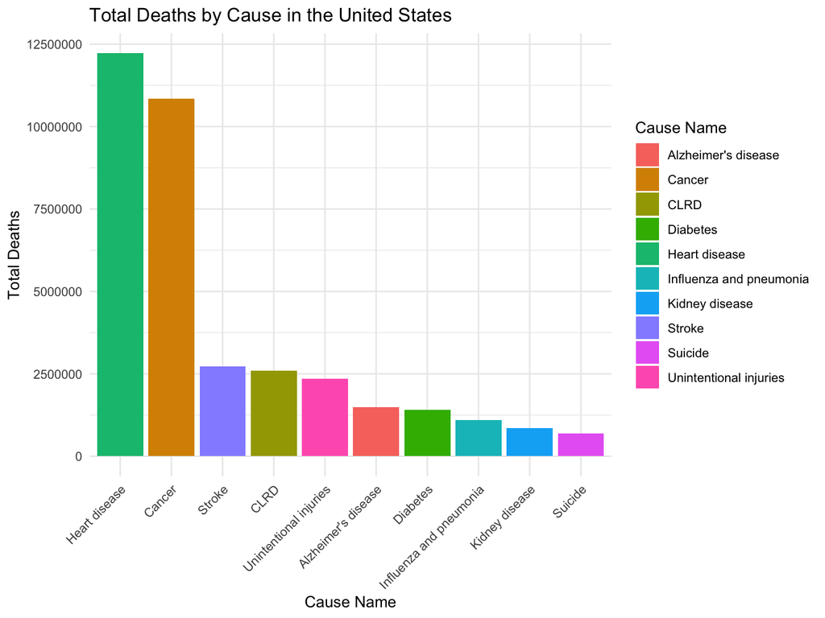

Now filter our data by total deaths for each state ordering from the least deaths to the most deathd for easy viewing.

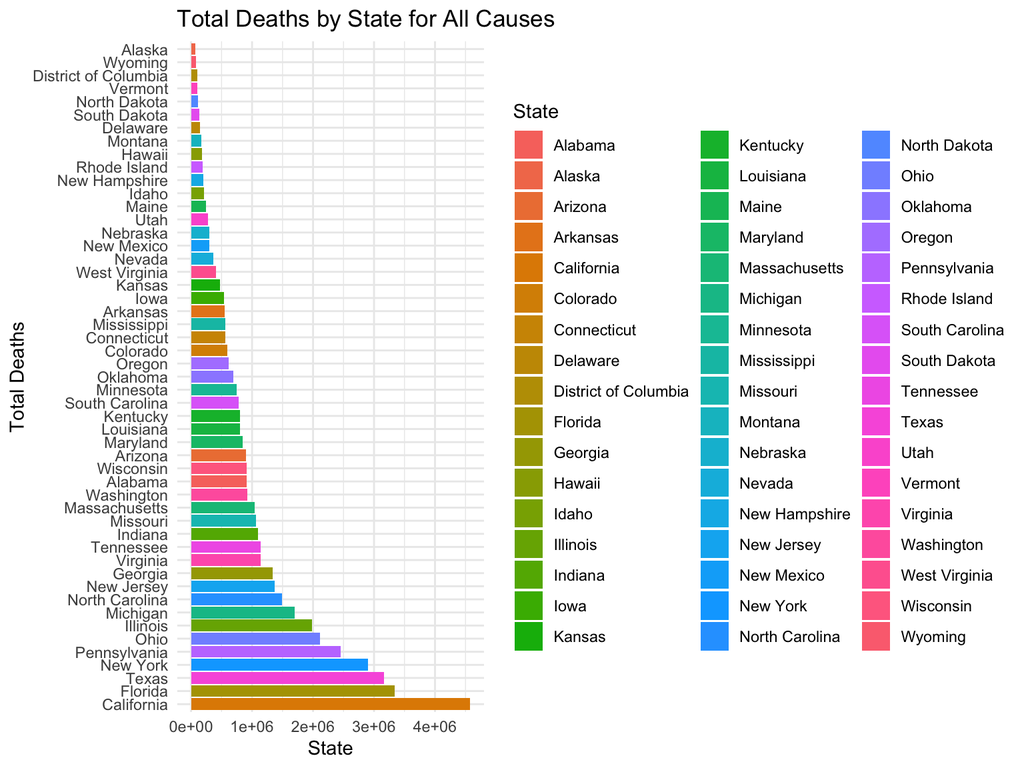

Now let’s filter it down to the top 5 causes and the top 10 states.

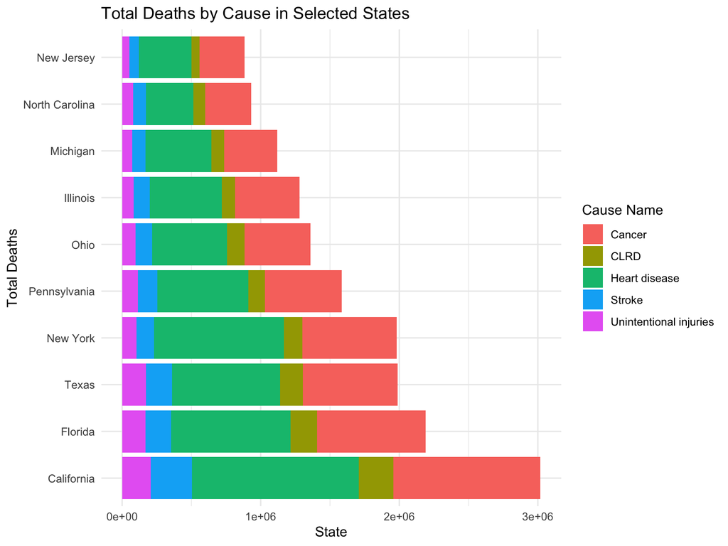

This shows that California has far more deaths than even the second closest state of Florida. California has triple the number of deaths from the top 5 causes once you look at North Carolina or New Jersey.

# A better way to look at causes?

It might look like some states have far more deaths from illness, but these states also have the largest populations.  
What if we used the Age-adjusted data?  
Would we get different results for states and causes?

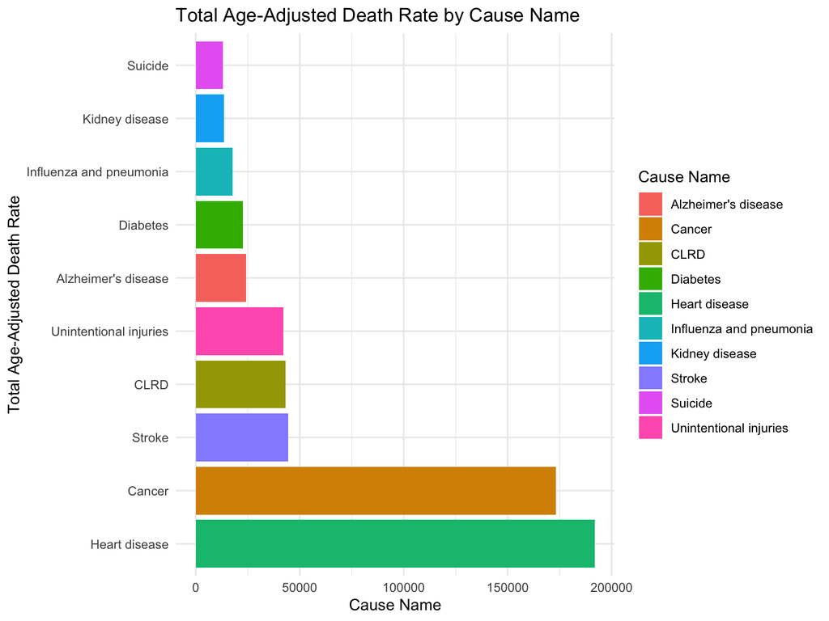

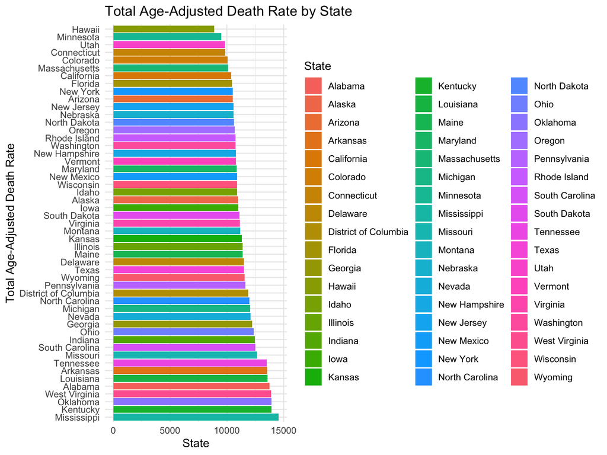

Now let’s look at the top 5 Age-Adjusted Death Causes and the Top 10 states

|  | Cause.Name | State | TotalAgeAdjustedDeathRate |
| --- | --- | --- | --- |
| 1 | CLRD | Alabama | 997.7 |
| 2 | CLRD | Arkansas | 1029.4 |
| 3 | CLRD | Kentucky | 1158.6 |
| 4 | CLRD | Louisiana | 813.4000000000002 |
| 5 | CLRD | Mississippi | 994.4000000000001 |
| 6 | CLRD | Missouri | 953.8000000000001 |
| 7 | CLRD | Oklahoma | 1154.2 |
| 8 | CLRD | South Carolina | 894 |
| 9 | CLRD | Tennessee | 998.9000000000001 |
| 10 | CLRD | West Virginia | 1169.1 |

[output cut: 40 more lines]

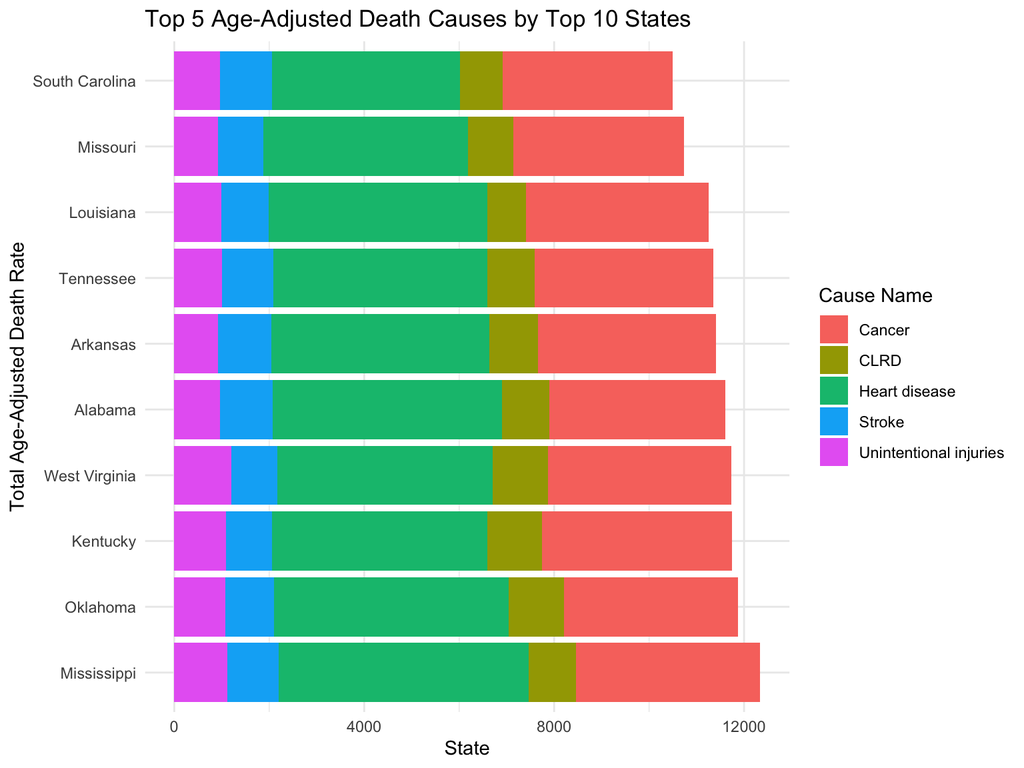

```
## # A tibble: 11 × 3
## # Groups:   Cause.Name [11]
##     Year Cause.Name               Deaths
##    <int> <chr>                     <int>
##  1  2017 All causes              2813503
##  2  2017 Alzheimer's disease      121404
##  3  2017 CLRD                     160201
##  4  2017 Cancer                   599108
##  5  2017 Diabetes                  83564
##  6  1999 Heart disease            725192
##  7  2002 Influenza and pneumonia   65681
##  8  2017 Kidney disease            50633
##  9  2000 Stroke                   167661
## 10  2017 Suicide                   47173
## 11  2017 Unintentional injuries   169936
```

# Using per capita

Let’s look at the deaths using population per capita to see if that changes the results.  
I am going to pick 2010 and load population data from the census.

```r
# Creating a data frame with state populations from the 2010 Census
state_populations_2010 <- data.frame(
  State = c(
    "Alabama", "Alaska", "Arizona", "Arkansas", "California", "Colorado",
    "Connecticut", "Delaware", "District of Columbia", "Florida", "Georgia", "Hawaii", "Idaho",
    "Illinois", "Indiana", "Iowa", "Kansas", "Kentucky", "Louisiana",
    "Maine", "Maryland", "Massachusetts", "Michigan", "Minnesota", "Mississippi",
    "Missouri", "Montana", "Nebraska", "Nevada", "New Hampshire", "New Jersey",
    "New Mexico", "New York", "North Carolina", "North Dakota", "Ohio", "Oklahoma",
    "Oregon", "Pennsylvania", "Rhode Island", "South Carolina", "South Dakota",
    "Tennessee", "Texas", "Utah", "Vermont", "Virginia", "Washington", "West Virginia",
    "Wisconsin", "Wyoming"
  ),
  Population_2010 = c(
    4779736, 710231, 6392017, 2915918, 37253956, 5029196,
    3574097, 897934, 601723, 18801310, 9687653, 1360301, 1567582,
    12830632, 6483802, 3046355, 2853118, 4339367, 4533372,
    1328361, 5773552, 6547629, 9883640, 5303925, 2967297,
    5988927, 989415, 1826341, 2700551, 1316470, 8791894,
    2059179, 19378102, 9535483, 672591, 11536504, 3751351,
    3831074, 12702379, 1052567, 4625364, 814180, 6346105,
    25145561, 2763885, 625741, 8001024, 6724540, 1852994,
    5686986, 563626
  )
)
```

[figure not shown]

```
##            State Deaths_Per_Capita
## 1  West Virginia         11.481419
## 2        Alabama         10.050346
## 3       Arkansas          9.916603
## 4   Pennsylvania          9.808871
## 5    Mississippi          9.761409
## 6       Oklahoma          9.737559
## 7       Kentucky          9.674913
## 8          Maine          9.598294
## 9           Ohio          9.423219
## 10     Tennessee          9.388121
```

This map shows the deaths per 1,000 people for people who died because of cancer for each state. The lower table gives the numbers for the top 10 states.

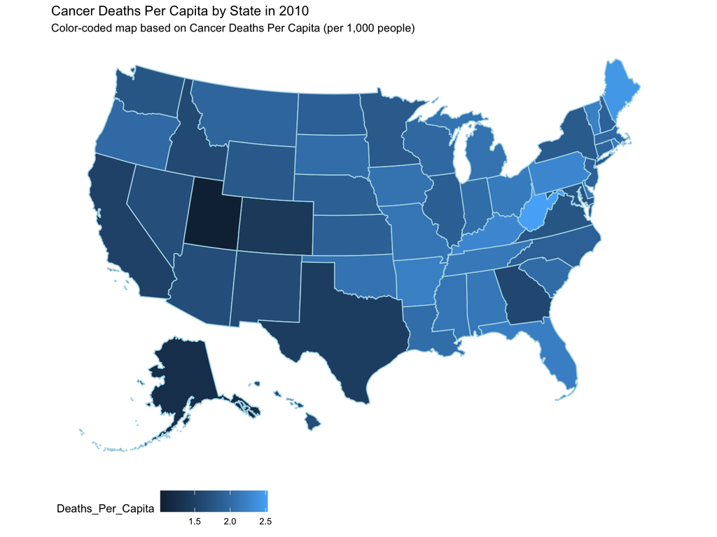

```
##            State Deaths_Per_Capita
## 1  West Virginia          2.528341
## 2          Maine          2.445118
## 3       Kentucky          2.288352
## 4   Pennsylvania          2.287367
## 5        Vermont          2.224563
## 6       Arkansas          2.220570
## 7        Florida          2.205538
## 8           Ohio          2.174229
## 9   Rhode Island          2.152832
## 10     Tennessee          2.141944
```

This map shows the deaths per 100,000 people for people who died because of suicide for each state. The lower table gives the numbers for the top 10 states.

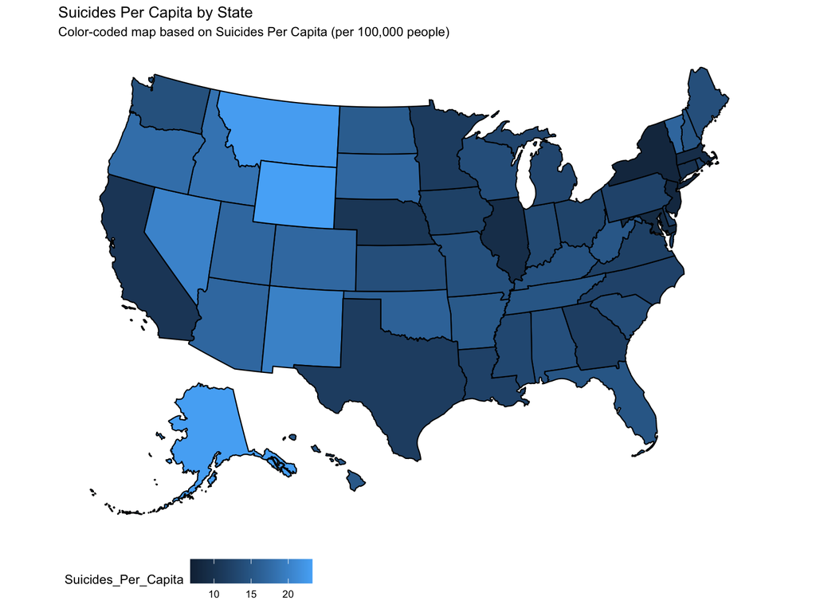

```
##           State Suicides_Per_Capita
## 1       Wyoming            23.24236
## 2        Alaska            23.09108
## 3       Montana            22.94285
## 4        Nevada            20.25513
## 5    New Mexico            20.05654
## 6         Idaho            18.49983
## 7        Oregon            17.88010
## 8      Colorado            17.19957
## 9  South Dakota            17.19521
## 10         Utah            17.11359
```